# exploring_melanoma_signatures

Lewis E Tomalin, PhD

2025-08-21

## Let’s set the scene

We have *three* RGP signatures.

- **rgp_no_adj:** created in ‘tissue_type_degs’
- **rgp_canonical_kc_adj:** created in ‘tissue_type_degs_canonical_kc_adjust’
- rgp_xcell_kc_adj: created in ‘tissue_type_degs_xcell_kc_adjust’

We have *three* VGP signatures.

- vgp_no_adj: created in ‘tissue_type_degs’
- vgp_canonical_kc_adj: created in ‘tissue_type_degs_canonical_kc_adjust’
- vgp_xcell_kc_adj: created in ‘tissue_type_degs_xcell_kc_adjust’

We also have *three* signatures for genes associated with keratinocytes

- xcell_kc_assoc: created in ‘genes_associated_with_xcell_kc’
- canonical_kc_gsva_assoc: created in ‘genes_associated_with_canonical_kc_gsva’
- canonical_kc_ssgsea_assoc: created in ‘genes_associated_with_canonical_kc_ssgsea’

From these signatures we can create 9 more signatures by removing the keratinocyte signature genes from the RGP signatures.

- rgp_no_adj_xcell_kc_assoc:
- rgp_no_adj_canonical_kc_gsva_assoc:
- rgp_no_adj_ssgsea_assoc:
- rgp_canonical_kc_adj_xcell_kc_assoc:
- rgp_canonical_kc_adj_canonical_kc_gsva_assoc:
- rgp_canonical_kc_adj_ssgsea_assoc:
- rgp_xcell_kc_adj_xcell_kc_assoc:
- rgp_xcell_kc_adj_canonical_kc_gsva_assoc:
- rgp_xcell_kc_adj_ssgsea_assoc:

and the VGP signatures

- vgp_no_adj_xcell_kc_assoc:
- vgp_no_adj_canonical_kc_gsva_assoc:
- vgp_no_adj_ssgsea_assoc:
- vgp_canonical_kc_adj_xcell_kc_assoc:
- vgp_canonical_kc_adj_canonical_kc_gsva_assoc:
- vgp_canonical_kc_adj_ssgsea_assoc:
- vgp_xcell_kc_adj_xcell_kc_assoc:
- vgp_xcell_kc_adj_canonical_kc_gsva_assoc:
- vgp_xcell_kc_adj_ssgsea_assoc:

Additionally, we have a list of genes that contain *KRT* in their name.

We make a further set of RGP and VGP signatures with these KRT genes removed.

- rgp_no_adj_no_krt_genes:
- rgp_canonical_kc_adj_no_krt_genes:
- rgp_xcell_kc_adj_no_krt_genes:
- vgp_no_adj_no_krt_genes:
- vgp_canonical_kc_adj_no_krt_genes:
- vgp_xcell_kc_adj_no_krt_genes:

## Screening RGP melanoma signatures for association with xCell KC score

Here we screen our signatures for association with xCell KC scores.

1. We do this using linear mixed-effects models, focusing on rgp first

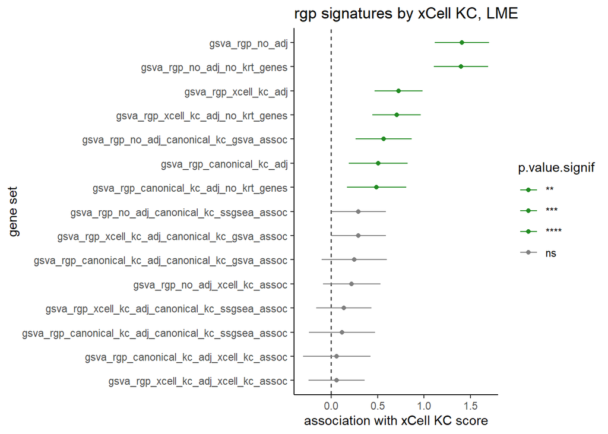

Let’s take a closer look at the model to get some interpretation.

```r
load('exploring_melanoma_signatures/results/melanoma_enrichment_scores.rda')

L <- 'gsva_rgp_canonical_kc_adj'

melanoma_enrichment_scores$asin_xcell_keratinocytes <- asin(sqrt(melanoma_enrichment_scores$xcell_keratinocytes))

lmer(gsva_rgp_xcell_kc_adj_xcell_kc_assoc ~ asin_xcell_keratinocytes + final_tissue_type_category + age_centered_impute + sex + (1|patient_id),
     data=melanoma_enrichment_scores) -> mod3

summary(mod3)
```

[output not shown]

2. We can also check this using pearson correlation.

This will be less precise as it won’t account for covariates.

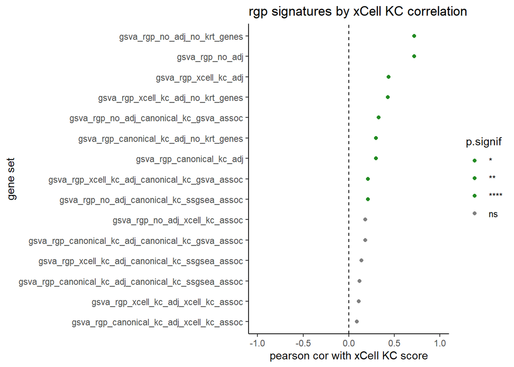

The signature with the least association with xcell KC score was *gsva_rgp_xcell_kc_adj_xcell_kc_assoc*.

- rgp_xcell_kc_adj: created in …
- xcell_kc_assoc: created in …
- rgp_xcell_kc_adj_xcell_kc_assoc: genes from rgp_xcell_kc_adj minus genes from xcell_kc_assoc

### Let’s validate these signatures against QuPath score

Note that there is no Nevus here, so it is not an apples to apples comparison

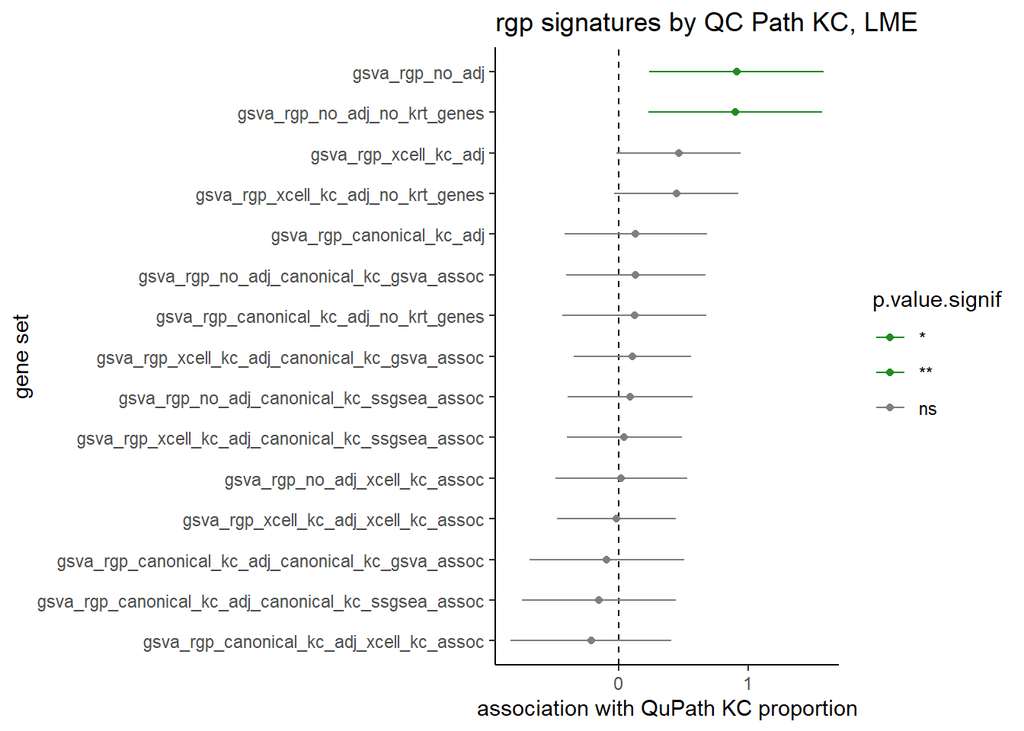

Let’s take a closer look at the model to get some interpretation.

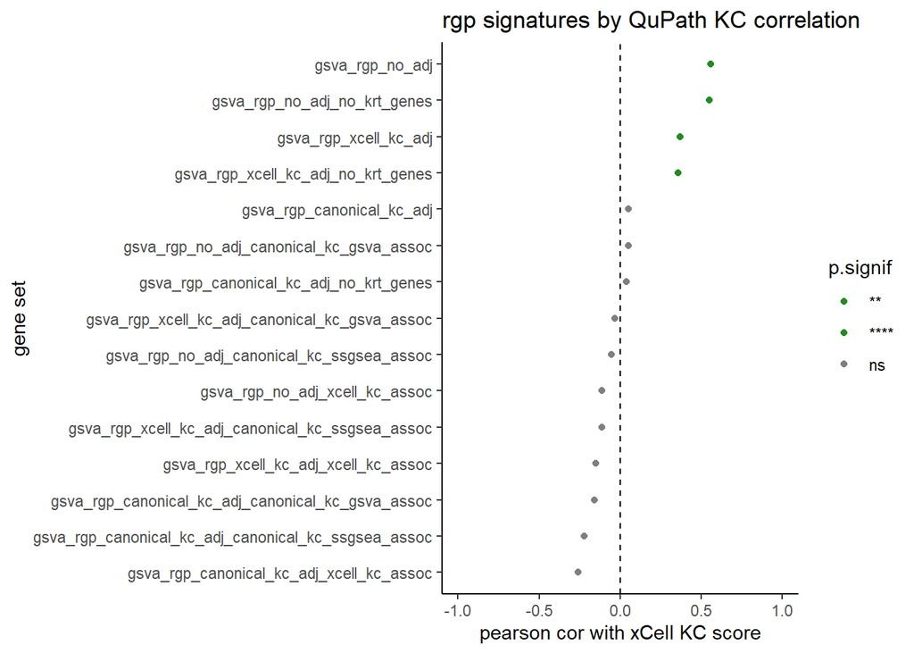

```r
load('exploring_melanoma_signatures/results/melanoma_enrichment_scores.rda')

L <- 'gsva_rgp_xcell_kc_adj_xcell_kc_assoc'

melanoma_enrichment_scores %>%
  filter(complete.cases(detections)) %>%
  mutate(kc_proportion=keratinocyte/detections,
         kc_proportion_asin=asin(sqrt(kc_proportion))) -> data_temp

lmer(gsva_rgp_xcell_kc_adj_xcell_kc_assoc ~ kc_proportion_asin + final_tissue_type_category + age_centered_impute + sex + (1|patient_id),
     data=data_temp) -> mod3

summary(mod3)
```

[output not shown]

## Let’s check association with oncogenic MAPK

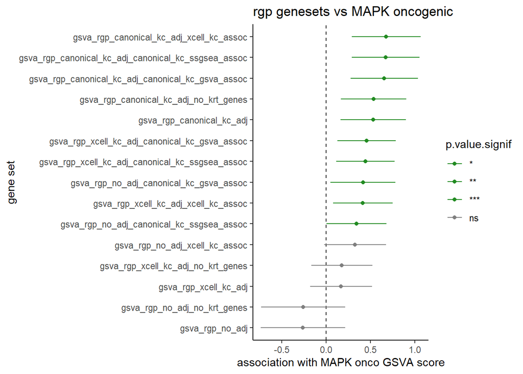

## Let’s valdate against canonical KC score

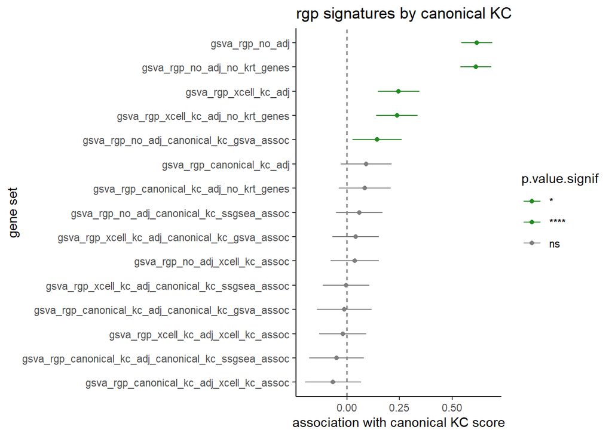

## Let’s repeat the above analysis for VGP

Here we screen our signatures for association with xCell KC scores.

1. We do this using linear mixed-effects models, focusing on vgp

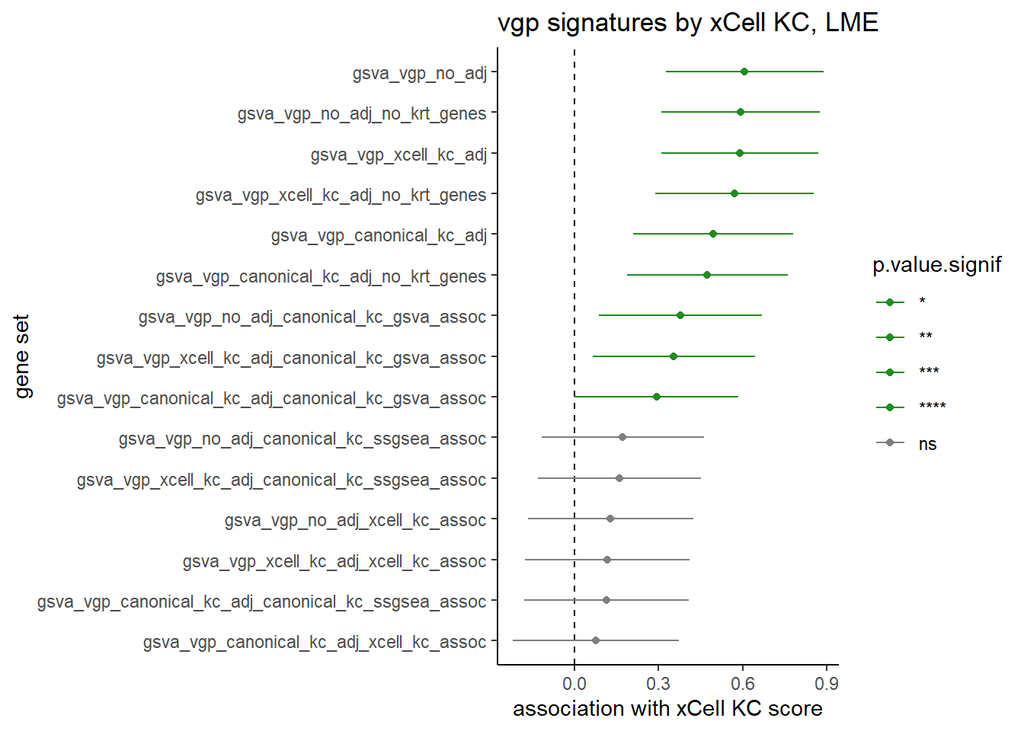

2. We can also check this using pearson correlation.

This will be less precise as it won’t account for covariates.

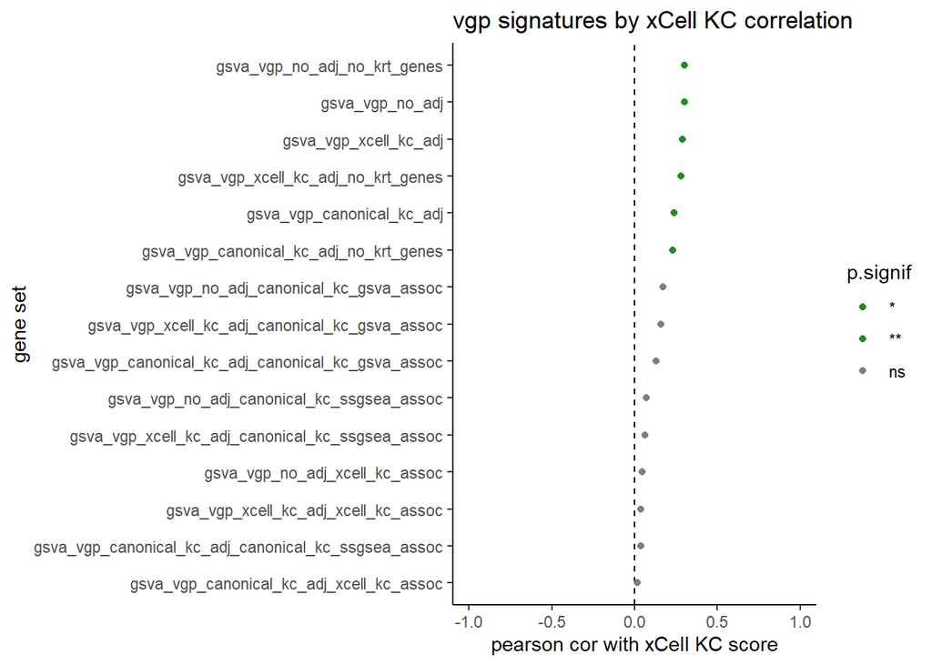

- rgp_xcell_kc_adj: created in …
- xcell_kc_assoc: created in …
- rgp_xcell_kc_adj_xcell_kc_assoc: genes from rgp_xcell_kc_adj minus genes from xcell_kc_assoc

### Let’s validate these signatures against QuPath score

Note that there is no Nevus here, so it is not an apples to apples comparison

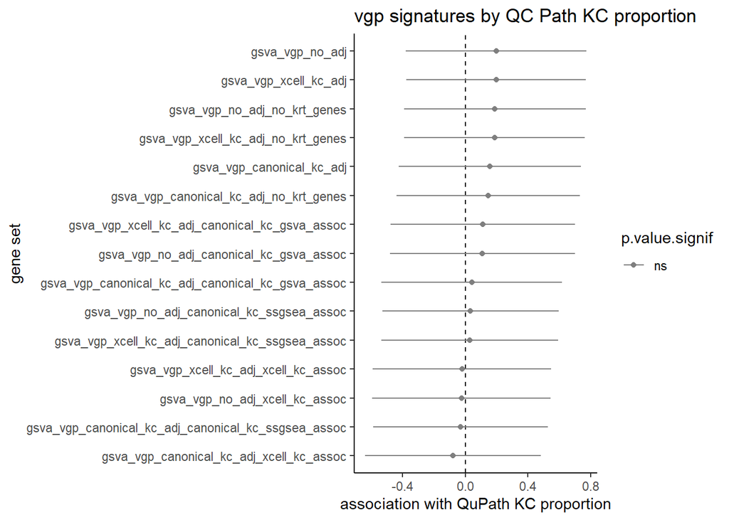

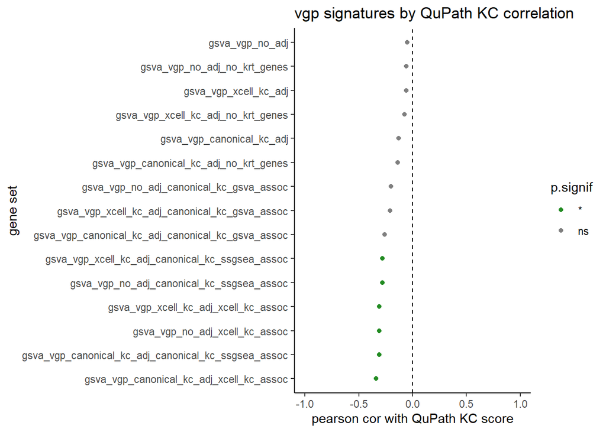

## Let’s check association with oncogenic MAPK

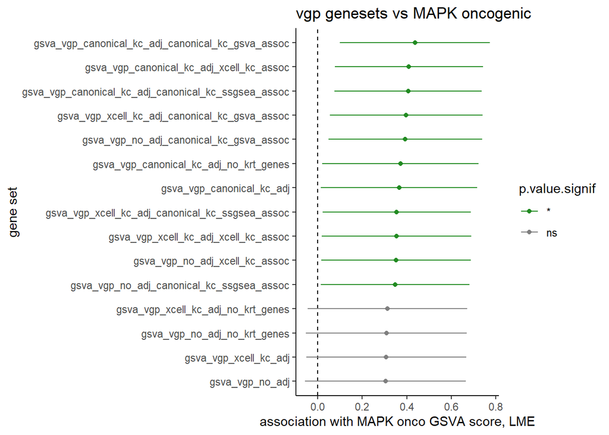

## Let’s valdate against canonical KC score

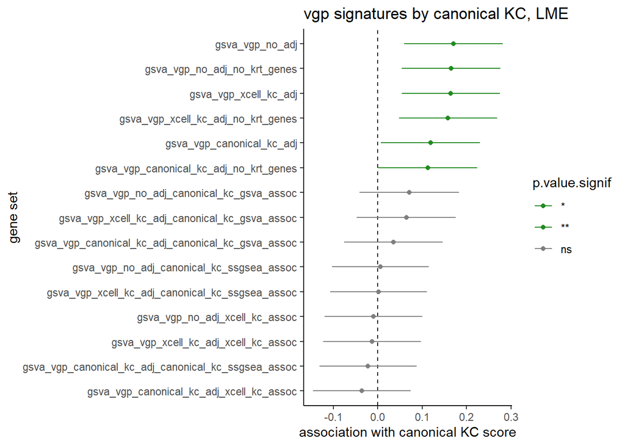

## PCA plots exploring KC adjustment

The PCA plot below is adjusted for

- mean variance trend (voom)
- xcell KC score
- age
- sex
- patient-id

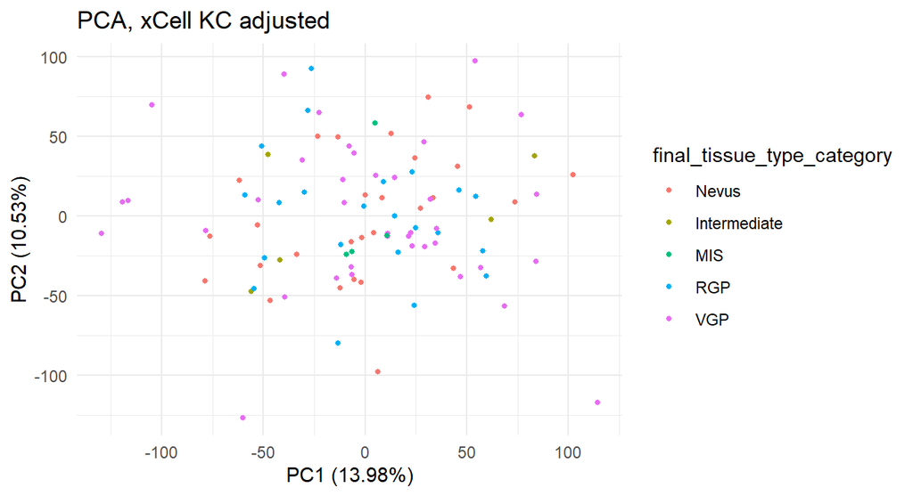

The PCA plot below is adjusted for

- mean variance trend (voom)
- xcell KC score
- age
- sex
- patient-id

and then selects the Top 500 most variable genes

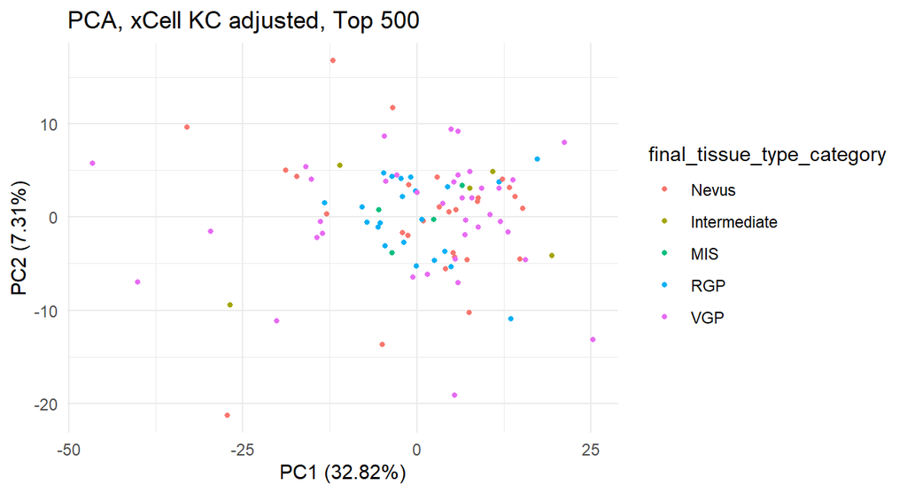

The PCA plot below is adjusted for

- mean variance trend (voom)
- xcell KC score
- age
- sex
- patient-id

and then then removes the ~4,000 genes that are associated with xcell KC score

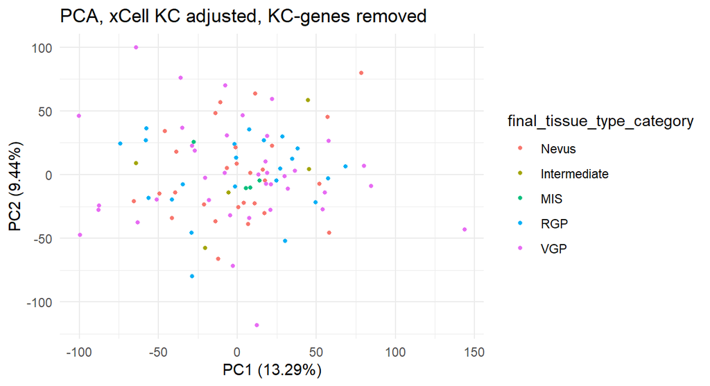

The PCA plot below is adjusted for

- mean variance trend (voom)
- xcell KC score
- age
- sex
- patient-id

and then then removes the ~4,000 genes that are associated with xcell KC score

and then selects the Top 500 most variable genes

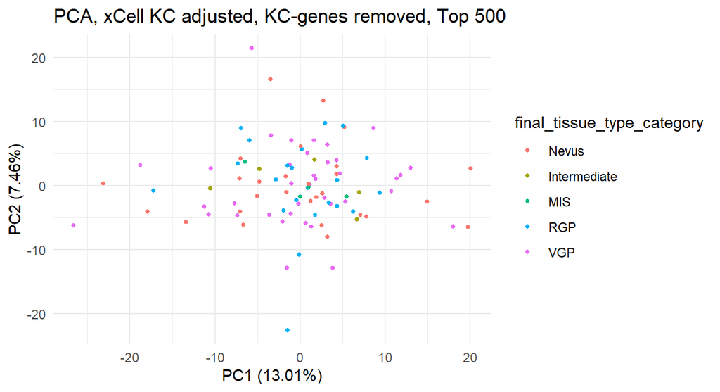

```
##             contrast Down    NS  Up
## 1       MIS_vs_Nevus   47 16946   3
## 2       RGP_vs_Nevus  483 16214 299
## 3       VGP_vs_Nevus 1002 15254 740
## 4         VGP_vs_MIS   55 16871  70
## 5         VGP_vs_RGP   79 16836  81
## 6    RGP_vs_Intermed   31 16874  91
## 7    VGP_vs_Intermed  541 15878 577
## 8         RGP_vs_MIS   NA 16996  NA
## 9    MIS_vs_Intermed   NA 16996  NA
## 10 Intermed_vs_Nevus   NA 16996  NA
```

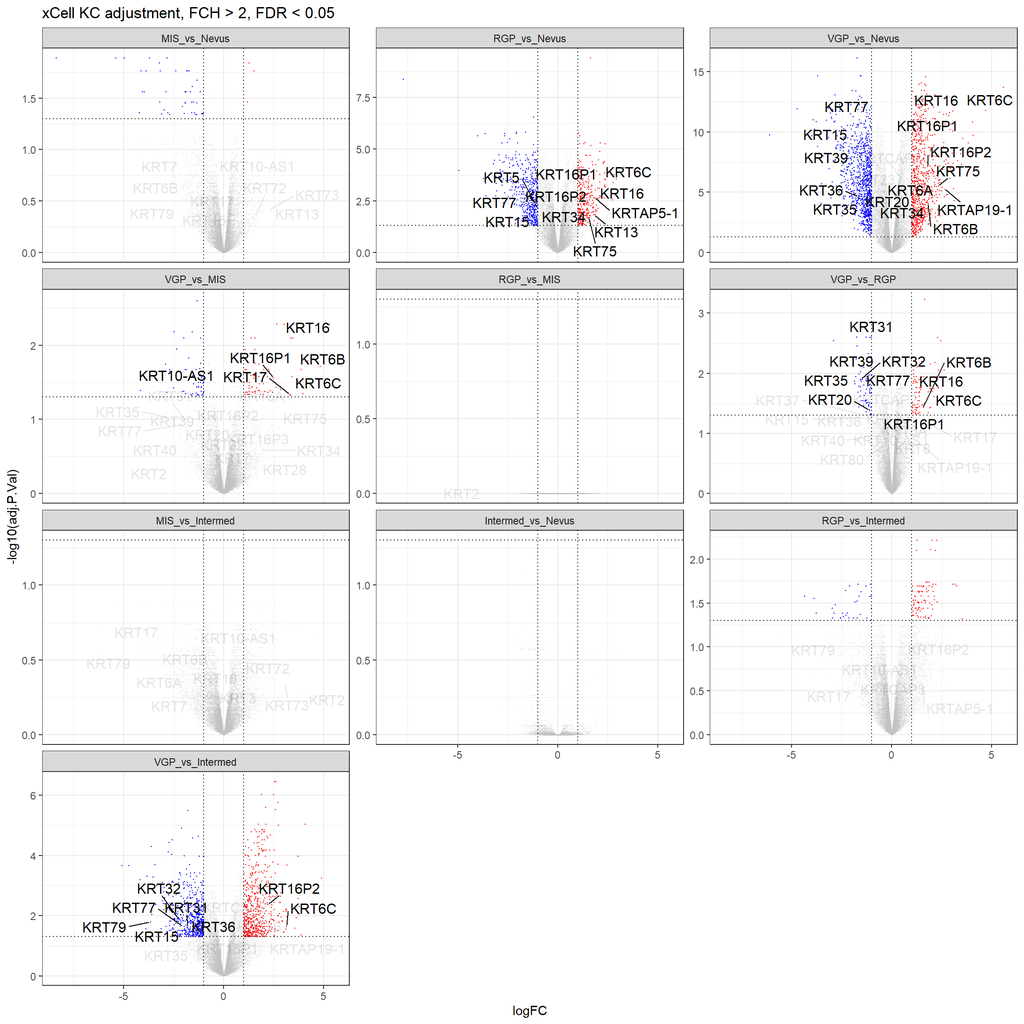

### The code below addresses the the inconsistencies with previous analysis.

Below shows correlation of RGP signatures with canonical KC.

Remember, correlation is crude, and does not account for covariates and repeated measures.

The LME models used above are more precise.

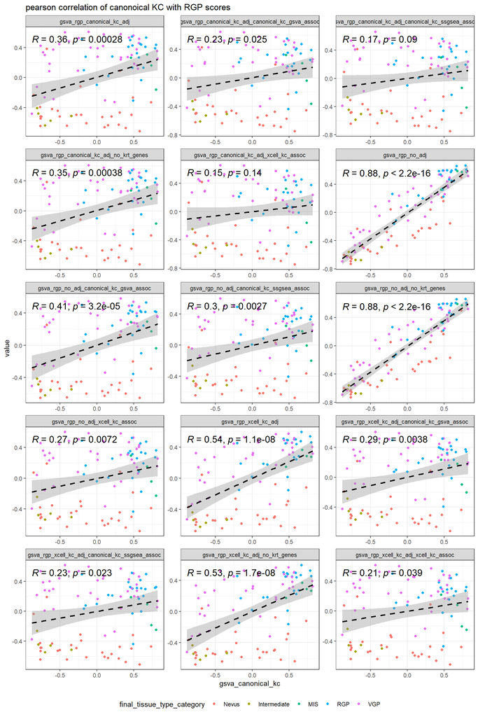

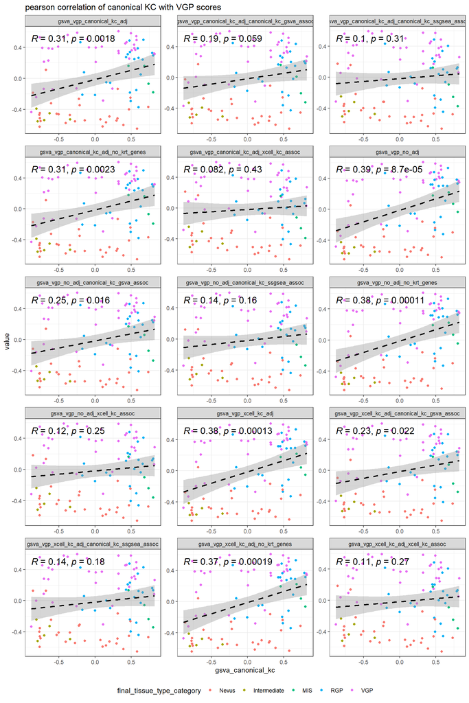

and below is with spearman,…

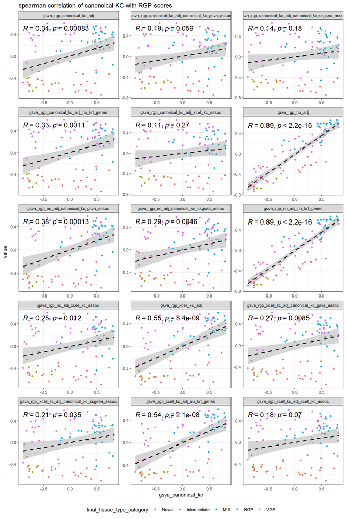

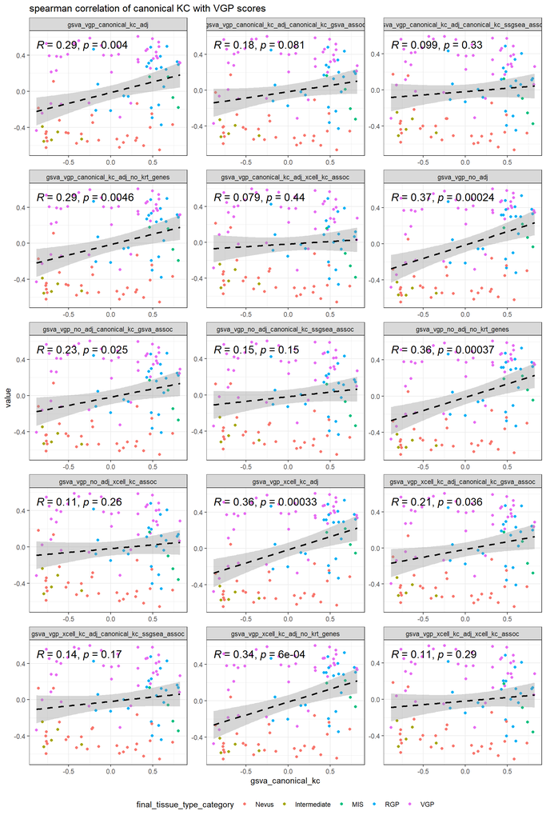

FCH > 2, FDR < 0.05

model1 = final_tissue_type_category + sex + age_centered_impute + (1 | patient_id)

MAPK